# Analysis of Weather Events impacting Health and Economy in USA

Yang Yuzhong

3/18/2015

## Synopsis

This report outlines the analysis done to determine the impact of various weather events on the economy and health of United States. The data used in this report is based on the 1950 - 2011 storm database collected from U.S. National Oceanic and Atmospheric Administration’s (NOAA).

Due to fewer events recorded for years earlier than 1996, the analysis was only performed on years between 1996-2011. The metrics for determining weather event impacts are `Fatalities` and `Injuries` for health impact and `Property Damage` and `Crop Damage` for economic impact.

The analysis results has shown that *Tornado* caused the highest number of casualties and *Flood* caused the highest economic damage to United States between 1996-2011. Also, *Flood* related events are highly ranked in terms of impact to United States’ health and economy.

## Data Processing

### Setting Up of Dataset and Environment

```r
library(R.utils)
```

```r
library(ggplot2)
library(dplyr)
setwd("~/workspace//Reproducible Research/RepData_PeerAssessment2/")

if (!"repdata_data_StormData.csv.bz2" %in% dir()) {
    download.file("http://d396qusza40orc.cloudfront.net/repdata%2Fdata%2FStormData.csv.bz2",
        destfile = "repdata_data_StormData.csv.bz2")
    bunzip2("repdata_data_StormData.csv.bz2", overwrite=T, remove=F)
}

if ("repdata_data_StormData.csv" %in% dir()) {
    data<-read.csv("repdata_data_StormData.csv")
    names(data)<-tolower(names(data))
}
```

### Filtering the Dataset

The dataset is read in and all headers converted to lowercase with `tolower()` and `names()`. Next, `strptime()` and `format()` is performed on *bgn*date_ to extract the year for each entry in the dataset. *year* column is then added to the original dataset.

```r
datecol<-strptime(data$bgn_date, "%m/%d/%Y %H:%M:%S", tz="UTC")
datecol<-format(datecol, "%Y")

data<-mutate(data,year=datecol)
```

Following this, *datayear* was created to hold the count of records for each year in the dataset.Based on information from [Details of Storm Events](http://www.ncdc.noaa.gov/stormevents/details.jsp), years earlier than 1996 were filtered from the dataset with `%in%` operator so that we perform analysis on years that have the most holistic types of weather events.

```r
datayear<-data %>%
    group_by(year) %>%
    summarize(entries = length(evtype))

datayear<-datayear[datayear$year>1995,]

data<-filter(data,data$year %in% datayear$year)
```

Lastly, events without any fatalities, injuries, crop and property dmg are removed as they are not required to answer the questions for the analysis.

```r
data<-filter(data,fatalities != 0 | injuries != 0 | propdmg != 0 | cropdmg != 0)
```

### Determining health impact for each record

```r
data<-data %>%
    mutate(totalimpact=(data$fatalities + data$injuries))
```

### Determining economic impact for each record

To determine economic impact by event type, the true value of crop damage, derived from *cropdmg* and *cropdmgexp* containing the exponential multplier. This is the same for property damage with *propdmg* and *propdmgexp*. Then the total economic impact is obtained by the sum of crop and property damage.

To do this, codebook from [Investigative Reporters & Editors - Record Layout](http://ire.org/media/uploads/files/datalibrary/samplefiles/Storm%20Events/layout08.doc) were used for the character symbols in *cropdmgexp* and *propdmgexp*, were used to convert them into numeric format.

```r
data$cropdmgexp<-tolower(as.character(data$cropdmgexp))
data$cropdmgexp[data$cropdmgexp == "b"]<-"9"
data$cropdmgexp[data$cropdmgexp == "m"]<-"6"
data$cropdmgexp[data$cropdmgexp == "k"]<-"3"
data$cropdmgexp[data$cropdmgexp == "h"]<-"2"
data$cropdmgexp[data$cropdmgexp == ""]<-"0"
data$cropdmgexp[is.na(data$cropdmgexp)]<-"0"
data$cropdmgexp<-as.numeric(data$cropdmgexp)

data$propdmgexp<-tolower(as.character(data$propdmgexp))
data$propdmgexp[data$propdmgexp == "b"]<-"9"
data$propdmgexp[data$propdmgexp == "m"]<-"6"
data$propdmgexp[data$propdmgexp == "k"]<-"3"
data$propdmgexp[data$propdmgexp == "h"]<-"2"
data$propdmgexp[data$propdmgexp == ""]<-"0"
data$propdmgexp[is.na(data$propdmgexp)]<-"0"
data$propdmgexp<-as.numeric(data$propdmgexp)
```

After the conversion, a new column *totaldamage* that is the sum of crop and property damage is added to the dataset using `mutate()`.

```r
data<-data %>%
    mutate(totaldamage=(data$cropdmg * 10^data$cropdmgexp) +
               (data$propdmg * 10^data$propdmgexp))
```

### Merging Similar Event types

As the event types given in the dataset are too inconsistently named and manual merging of the event types into one of the 48 event types reflected in [Storm Data Documentation](https://d396qusza40orc.cloudfront.net/repdata%2Fpeer2_doc%2Fpd01016005curr.pdf) would be too tedious, a partial merging of similar event types that have high health and economic impact is performed.

Firstly, to determine the event types to merge, *healthimpact* and *economicimpact* are created by summing up *totalimpact* and *totaldamage* columns respectively then arranged in descending order. This helps in determining the top 20 high health and economic impact event types to perform merging to reduce the scope of merging similar event types.

```r
tophealth<- data %>%
    group_by(evtype) %>%
    summarize(totalimpact=sum(totalimpact)) %>%
    arrange(desc(totalimpact))

head(tophealth,n=20)
```

```
## Source: local data frame [20 x 2]
##
##               evtype totalimpact
## 1            TORNADO       22178
## 2     EXCESSIVE HEAT        8188
## 3              FLOOD        7172
## 4          LIGHTNING        4792
## 5          TSTM WIND        3870
## 6        FLASH FLOOD        2561
## 7  THUNDERSTORM WIND        1530
## 8       WINTER STORM        1483
## 9               HEAT        1459
## 10 HURRICANE/TYPHOON        1339
## 11         HIGH WIND        1318
## 12          WILDFIRE         986
## 13        HEAVY SNOW         805
## 14               FOG         772
## 15              HAIL         720
## 16  WILD/FOREST FIRE         557
## 17       RIP CURRENT         549
## 18      RIP CURRENTS         496
## 19          BLIZZARD         455
## 20         ICE STORM         400
```

```r
topeconomic<-data %>%
    group_by(evtype) %>%
    summarize(totaldamage=sum(totaldamage)) %>%
    arrange(desc(totaldamage))

head(topeconomic,n=20)
```

```
## Source: local data frame [20 x 2]
##
##               evtype  totaldamage
## 1              FLOOD 148919611950
## 2  HURRICANE/TYPHOON  71913712800
## 3        STORM SURGE  43193541000
## 4            TORNADO  24900370720
## 5               HAIL  17071172870
## 6        FLASH FLOOD  16557105610
## 7          HURRICANE  14554229010
## 8            DROUGHT  14413667000
## 9     TROPICAL STORM   8320186550
## 10         HIGH WIND   5881421660
## 11          WILDFIRE   5054139800
## 12         TSTM WIND   5031941790
## 13  STORM SURGE/TIDE   4642038000
## 14 THUNDERSTORM WIND   3780985440
## 15         ICE STORM   3657908810
## 16  WILD/FOREST FIRE   3108564830
## 17      WINTER STORM   1544687250
## 18        HEAVY RAIN   1313034240
## 19      EXTREME COLD   1308733400
## 20      FROST/FREEZE   1103566000
```

With the information on the top 20 health and economic impact event types, similar event types were merged under one label using `grep()`.

```r
data$evtype<-as.character(data$evtype)
data$evtype[grep("non.tstm",data$evtype,ignore.case=TRUE)]<-"STRONG WIND"
data$evtype[grep("thunderstorm|tstm",data$evtype,ignore.case=TRUE)]<-"THUNDERSTORM"
data$evtype[grep("wind",data$evtype,ignore.case=TRUE)]<-"STRONG WIND"
data$evtype[grep("^strong.wind|gusty.wind|^high.wind|^wind",
                 data$evtype,ignore.case=TRUE)]<-"STRONG WIND"
data$evtype[grep("flash flood",data$evtype,ignore.case=TRUE)]<-"FLASH FLOOD"
data$evtype[grep("^coastal flood|tidal flood|flooding/erosion",
                 data$evtype,ignore.case=TRUE)]<-"COASTAL FLOOD"
data$evtype[grep("flood",data$evtype,ignore.case=TRUE)]<-"FLOOD"
data$evtype[grep("rip",data$evtype,ignore.case=TRUE)]<-"RIP CURRENT"
data$evtype[grep("heat",data$evtype,ignore.case=TRUE)]<-"HEAT"
data$evtype[grep("fire",data$evtype,ignore.case=TRUE)]<-"WILDFIRE"
data$evtype[grep("freeze|cold",data$evtype,ignore.case=TRUE)]<-"COLD"
data$evtype[grep("surge",data$evtype,ignore.case=TRUE)]<-"STORM SURGE"
data$evtype[grep("hail",data$evtype,ignore.case=TRUE)]<-"HAIL"
```

After the merging of similar event types, *healthimpact* and *economicimpact* is created by summing of *totalimpact* and *totaldamage* columns respectively then arranged in descending order.

```r
healthimpact<- data %>%
    group_by(evtype) %>%
    summarize(totalimpact=sum(totalimpact)) %>%
    arrange(desc(totalimpact))

economicimpact<-data %>%
    group_by(evtype) %>%
    summarize(totaldamage=sum(totaldamage)/10^6) %>%
    arrange(desc(totaldamage))
```

## Results

After preprocessing the data, analysis are performed to determine weather events types that are most harmful w.r.t Population Health and had the greatest economic impact.

### Events Most Harmful with Respect to Population Health

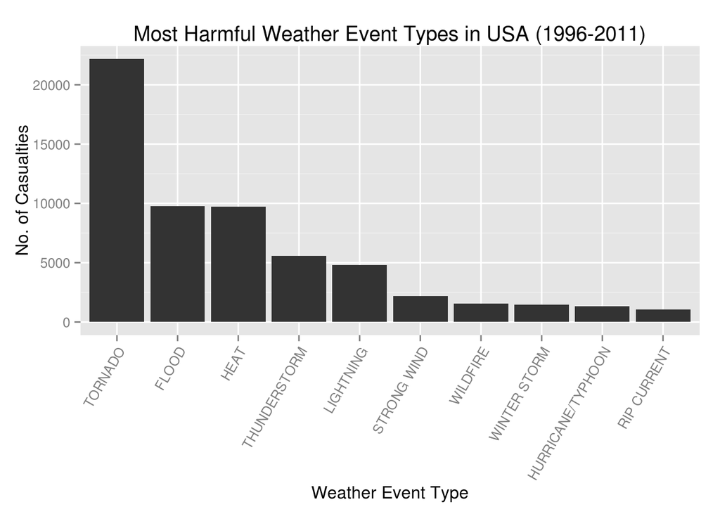

```r
healthdata<-healthimpact[1:10,]
healthdata$evtype<-factor(healthdata$evtype,
                          level = as.character(healthdata$evtype))
healthplot <- ggplot(data = healthdata, aes(x = evtype, y = totalimpact)) +
    theme(axis.text.x = element_text(angle = 60, hjust = 1)) +
    geom_bar(stat="identity") +
    ggtitle("Most Harmful Weather Event Types in USA (1996-2011)") +
    xlab("Weather Event Type") +
    ylab("No. of Casualties")
healthplot
```

### Events with Greatest Economic Consequences

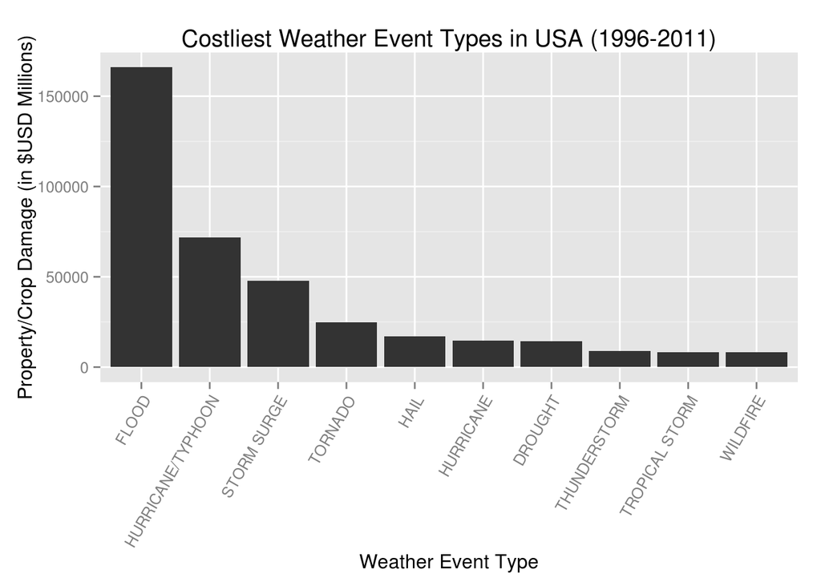

```r
econdata<-economicimpact[1:10,]
econdata$evtype<-factor(econdata$evtype,
                        level = as.character(econdata$evtype))
econplot<- ggplot(data = econdata, aes(x = evtype, y = totaldamage)) +
    theme(axis.text.x = element_text(angle = 60, hjust = 1)) +
    geom_bar(stat="identity") +
    ggtitle("Costliest Weather Event Types in USA (1996-2011)") +
    xlab("Weather Event Type") +
    ylab("Property/Crop Damage (in $USD Millions)")
econplot
```

### Conclusion

*Flood* related weather events rank highly in terms of economic impact and number of casualty. *Tornado* is 4th in terms of property/crop damage although it causes the highest number of casualties.